# TP2 Series Temporelles : Correction

Adrien Hardy

## Exercice 1

```r
set.seed(123)
?arima.sim
```

### Question (a)

Si $d=0$ on a un ARMA. Si de plus $d=0$, resp. $q=0$, on trouve un MA, resp. AR.

### Question (b)

$(1-B)^d X_t$ est la différentiation discrète d’ordre $d$ de $X_t$, notée $\Delta^d X_t$ dans le cours. Ainsi, ARIMA(p,d,q) est un modèle ARMA(p,q) pour la série temporelle $Y_t:=\Delta^d X_t$.

### Question (c)

#### AR(1) de paramètre $\phi_1=0.3$ et sa fonction d’autocorrélation :

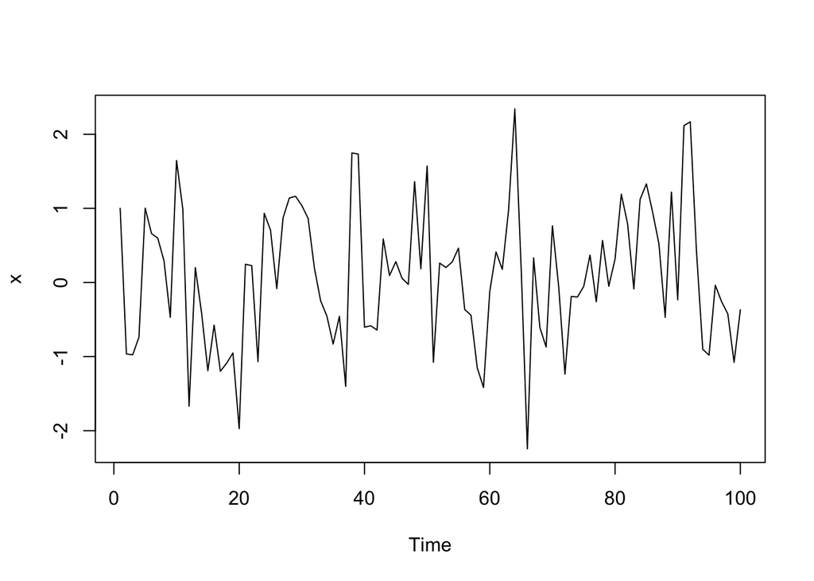

```r
x <- arima.sim(model=list(ar=0.3),n=100)
plot(x)
```

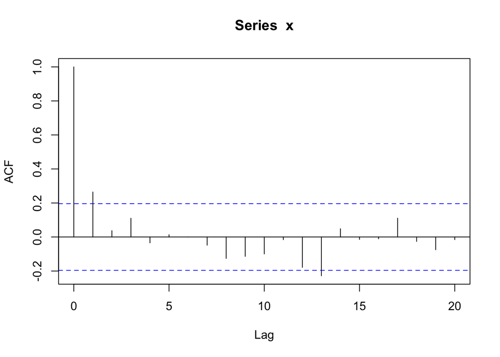

```r
acf(x)
```

#### AR(1) de paramètre $\phi_1=0.8$ et sa fonction d’autocorrélation :

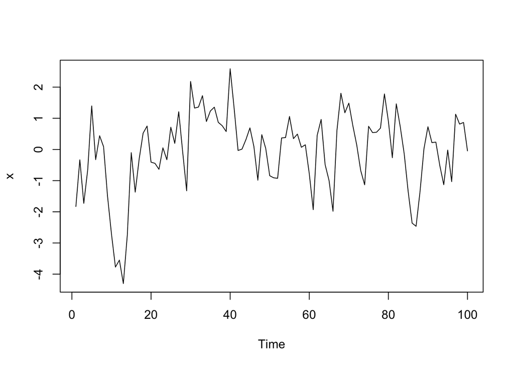

```r
x <- arima.sim(model=list(ar=0.8),n=100)
plot(x)
```

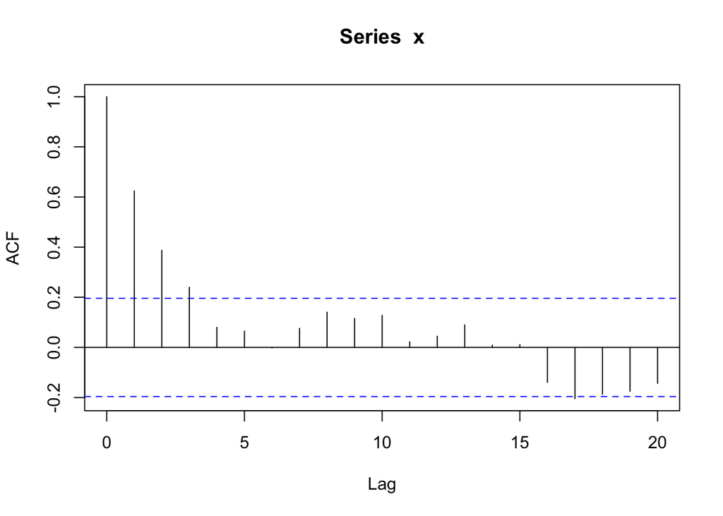

```r
acf(x)
```

On observe que le chronogramme est oscille un peu moins que quand $\phi=0.3$ : Il y a une plus forte corrélation ($\sim 1$) entre $X_t$ et $X_{t-1}$.

#### AR(1) de paramètre $\phi_1=-0.8$ et sa fonction d’autocorrélation :

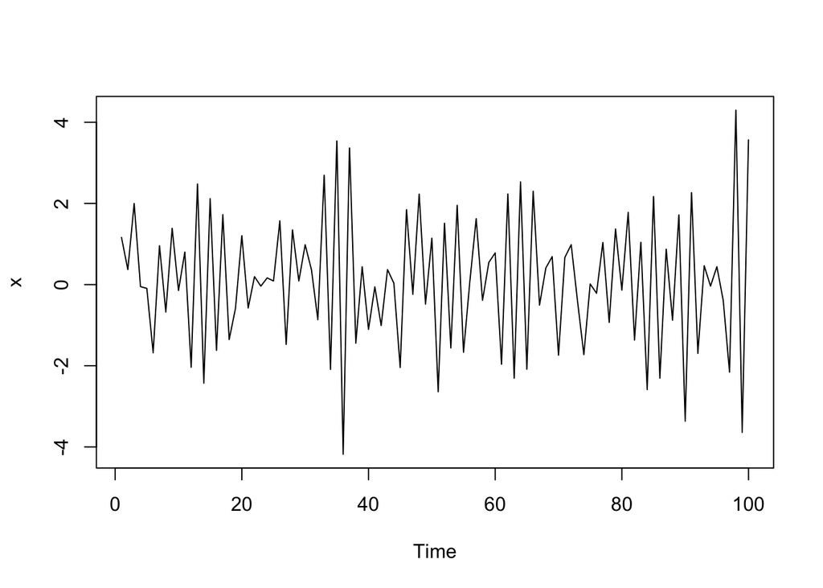

```r
x <- arima.sim(model=list(ar=-0.8),n=100)
plot(x)
```

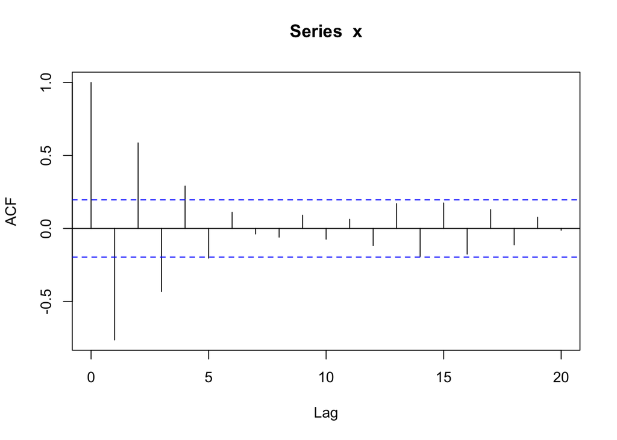

```r
acf(x)
```

A l’inverse, on a ici une forte anticorrélation $(\sim -1)$ entre $X_t$ et $X_{t-1}$ : Si $X_{t-1}$ est positive, il y a de fortes chances que $X_{t}$ soit alors négative et réciproquement $\Rightarrow$ Oscillations plus fréquentes.

### Question (d)

Par définition, un processus $X_t$ MA(q) satisfait :
$$X_t=\sum_{k=0}^q\theta_k\;\varepsilon_{t-k}\,,$$
où on a posé $\theta_0:=1$ pour simplifier. En posant également $\theta_k:=0$ pour $k>q$, on calcule pour tout $h\geq 0$ :
$$Cov(X_t,X_{t+h})=\sum_{k,\ell=0}^q\theta_k\theta_\ell \,Cov(\varepsilon_{t-k},\varepsilon_{t+h-\ell})=\sigma^2\sum_{k=0}^q\theta_k\theta_{k+h}$$
et donc :
$$\rho(h)=\frac{\sum_{k=0}^q\theta_k\theta_{k+h} }{\sum_{k=0}^q\theta_k^2 }.$$
En particulier, comme $\theta_k=0$ dès que $k>q$ par convention, on voit que $\rho(h)=0$ dès que $h>q$.

### Question (e)

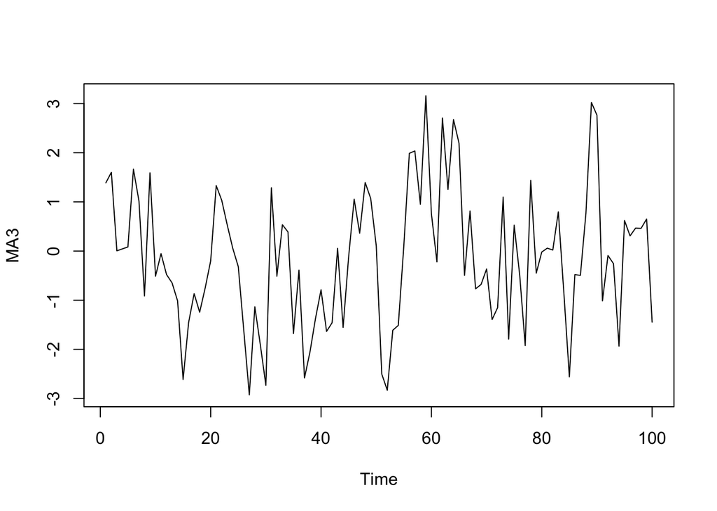

```r
MA3 <- arima.sim(list(ma=c(0.9,0.6,0.9)),n=100)
plot(MA3)
```

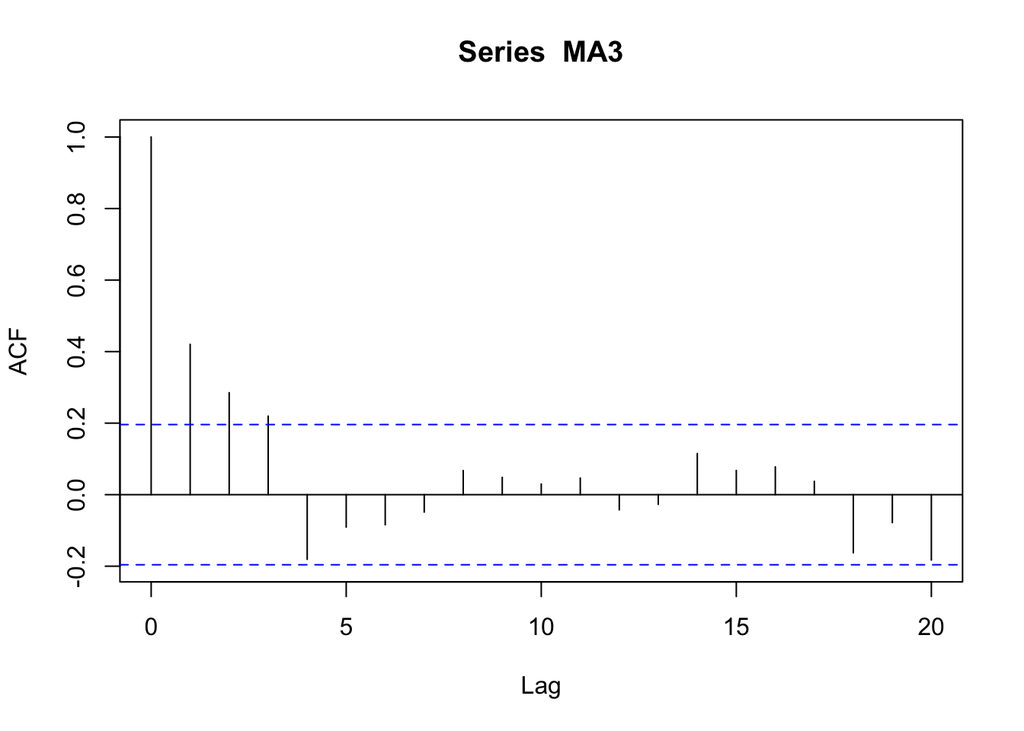

```r
acf(MA3)
```

### Question (f)

C’est un modèle ARMA(1,2) avec un bruit blanc $BB(0,1.5)$ gaussien. On voit dans l’aide de la commande $\verb'arima.sim'$ que le bruit utilisé est par défaut gaussien, et on spécifie l’écart-type comme suit :

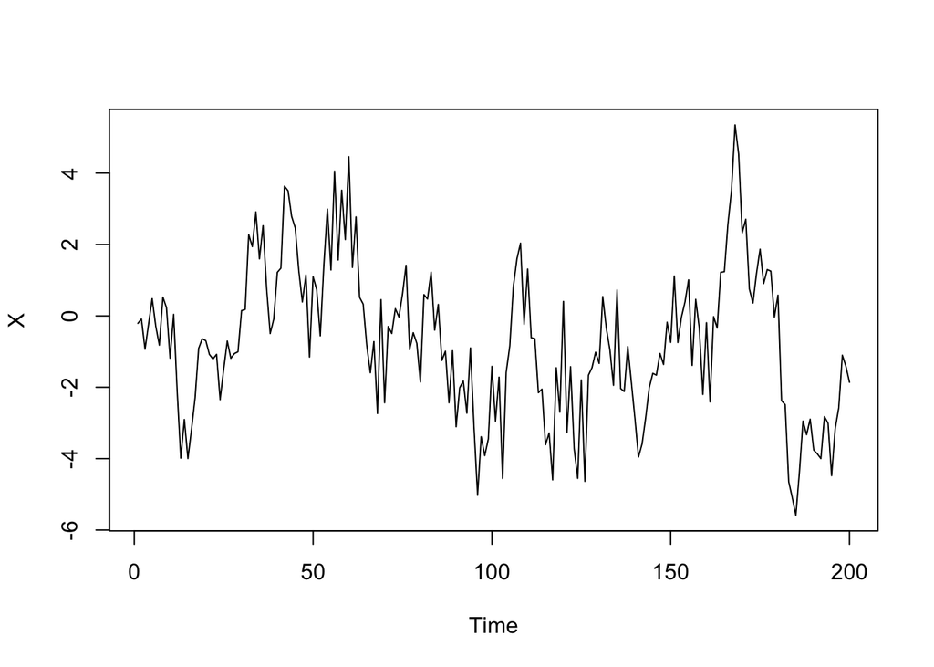

```r
X <- arima.sim(n=200,list(ar=c(0.8),ma=c(-0.3,0.6)),sd=sqrt(1.5))
plot(X)
```

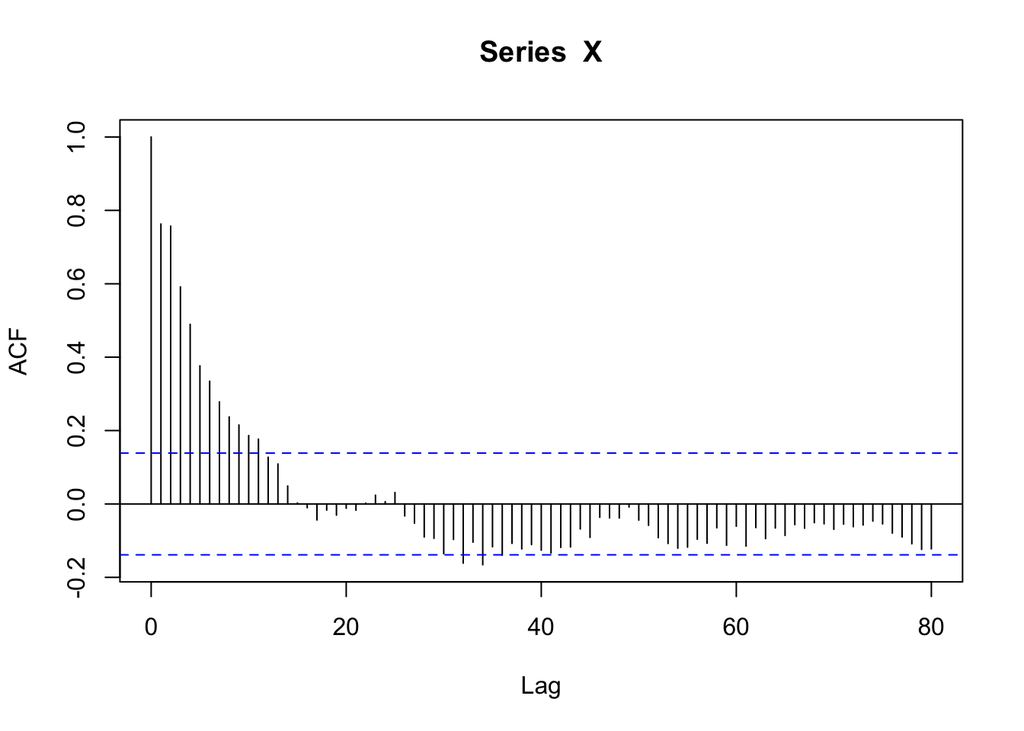

```r
acf(X, lag.max=80)
```

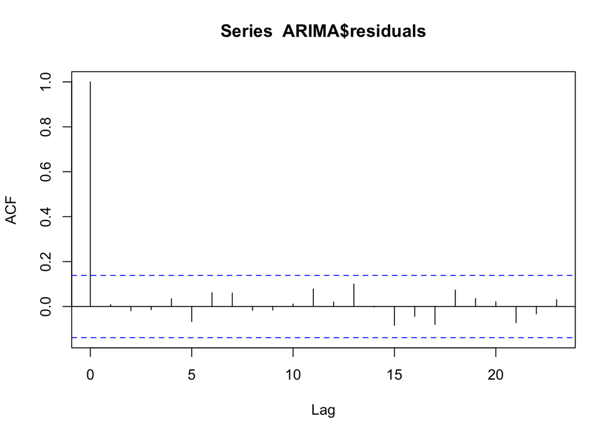

```r
ARIMA <- arima(X,order = c(1,0,2))
acf(ARIMA$residuals)
```

## EXERCICE 2

### Question (a)

Pour indexer la série temporelle par les trimestres en commençant par le deuxième trimestre de 1947, on fait comme ça :

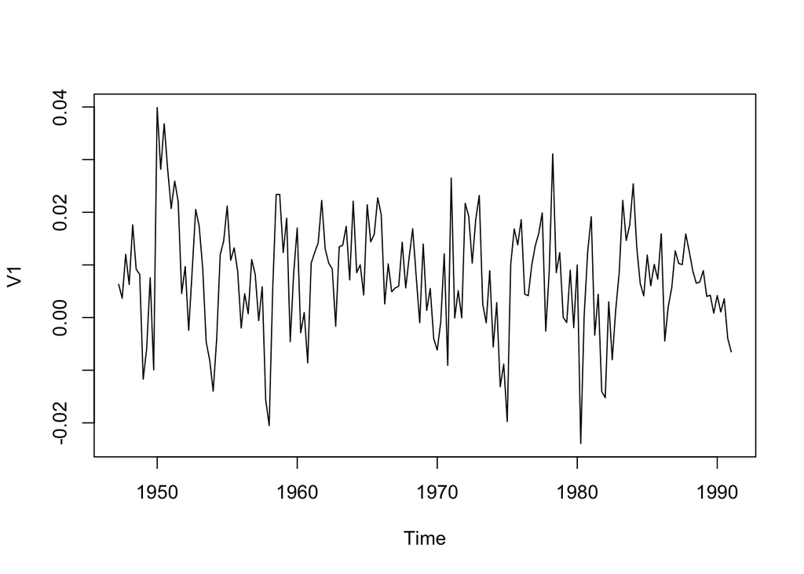

```r
gnpus_dat <- read.table("/Users/adrien/R/Data/gnpus.txt")
gnpus <- ts(gnpus_dat, frequency=4, start=c(1947,2))
plot(gnpus)
```

### Question (b) : Test de blancheur

```r
Box.test(gnpus)
```

```
##
##  Box-Pierce test
##
## data:  gnpus
## X-squared = 24.998, df = 1, p-value = 5.74e-07
```

On rejète donc l’hypothèse $H_0$ d’un bruit blanc vu la faible valeur de la p-valeur.

### Question (c) : Fonction d’autocorrélation empirique

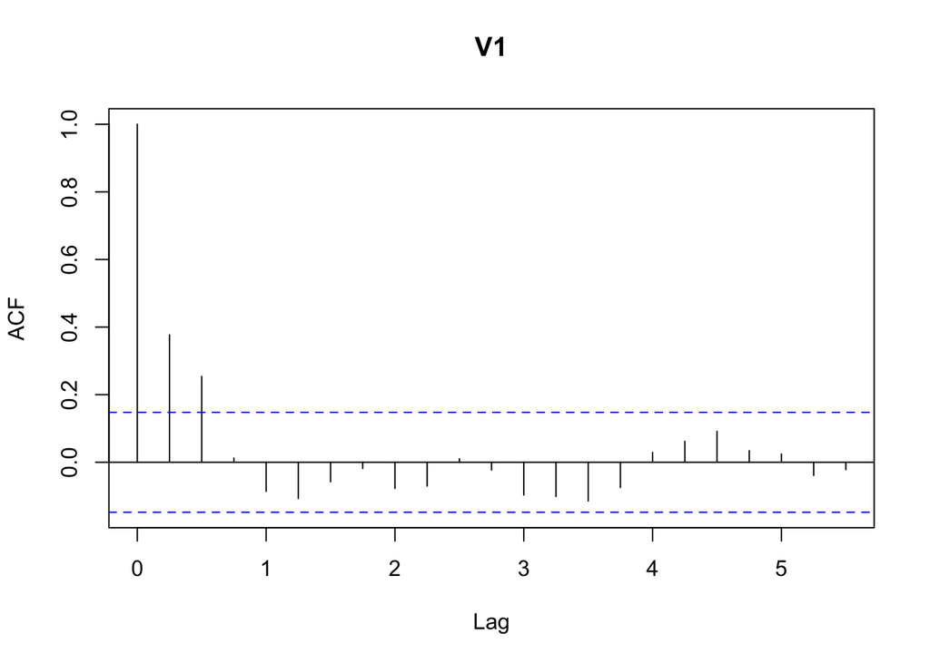

```r
acf(gnpus)
```

Vu l’ACF, on peut penser que cette série temporelle ressemble à un modèle AR, voir un MA(2).

### Question (d) : Modélisation avec un AR

```r
gnpusAR <- ar(gnpus)
gnpusAR
```

```
##
## Call:
## ar(x = gnpus)
##
## Coefficients:
##       1        2        3
##  0.3463   0.1770  -0.1421
##
## Order selected 3  sigma^2 estimated as  9.676e-05
```

Cette fonction nous propose donc un AR(3), de modèle :
$$X_t=0.3463X_{t-1}+0.177X_{t-2}-0.1421 X_{t-3}+\epsilon_t$$
où $\epsilon_t$ est un bruit blanc $BB(0,\sigma^2)$ de variance $\sigma^2=9.676\times 10^{-05}$.

### Question (e) : Etude des résidus

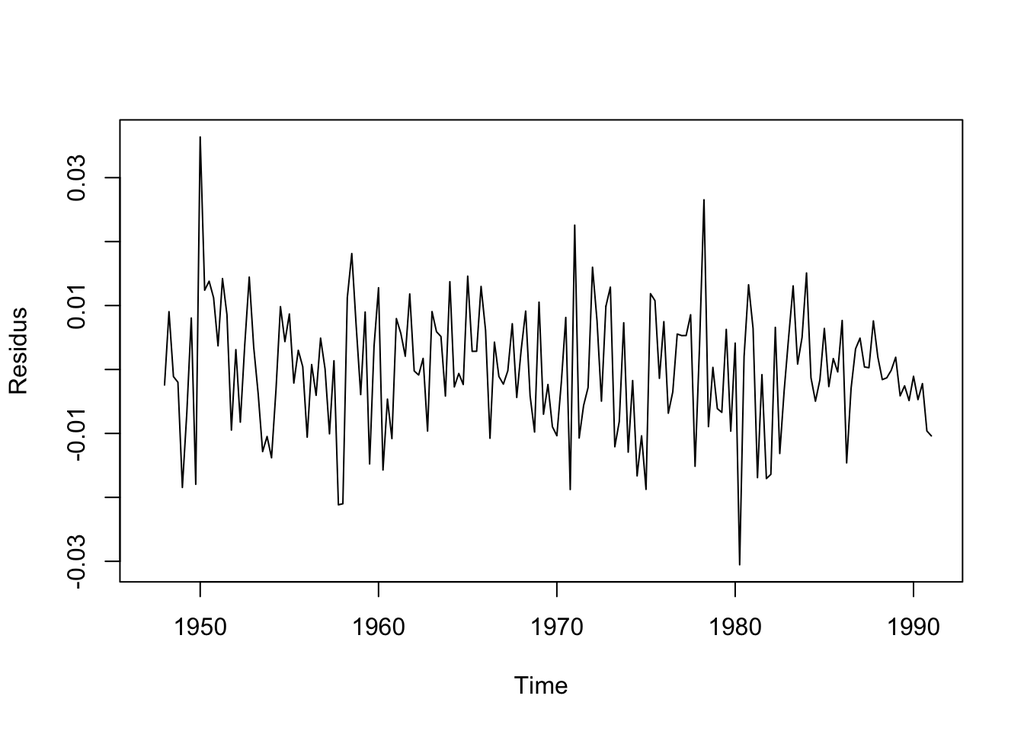

```r
Residus <- gnpusAR$resid
plot(Residus)
library(caschrono) # ce package contient la fonction Box.test.2
```

```r
Box.test.2(Residus,1:40)
```

```
##       Retard   p-value
##  [1,]      1 0.9115127
##  [2,]      2 0.9818001
##  [3,]      3 0.9415294
##  [4,]      4 0.8416601
##  [5,]      5 0.8444775
##  [6,]      6 0.9165832
##  [7,]      7 0.9214457
##  [8,]      8 0.8904874
##  [9,]      9 0.7792795
## [10,]     10 0.7562754
## [11,]     11 0.8220595
## [12,]     12 0.7840702
## [13,]     13 0.8329639
## [14,]     14 0.8165586
```

[output cut: 26 more lines]

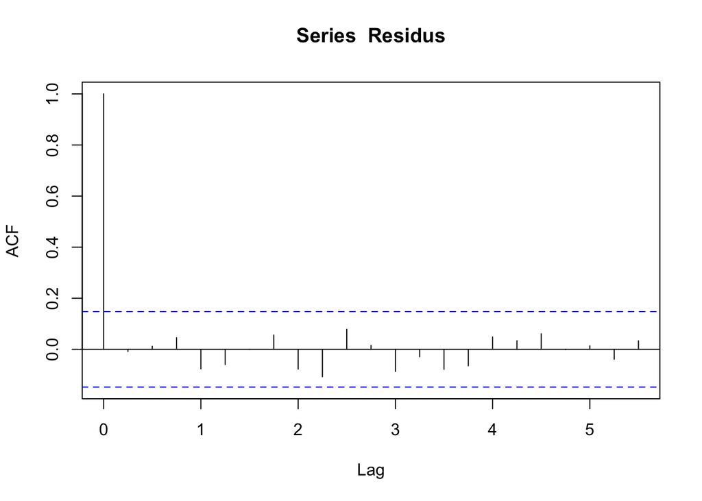

```r
acf(Residus,na.action=na.pass)
```

```r
shapiro.test(Residus)
```

```
##
##  Shapiro-Wilk normality test
##
## data:  Residus
## W = 0.98906, p-value = 0.2031
```

Au vu de l’acf et du test de Box-Pierce effectué pour un lag $h$ variant de $1$ à $40$, qui ne rejète jamais $H_0$, il n’est pas aberrant de supposer que les résidus forment un bruit blanc. De plus, le test de Shapiro-Wilk ne rejète pas non plus l’hypothèse de normalité des résidus. On peut donc conclure que la modélisation AR(3) ci-dessus est raisonnable, et que l’on peut même supposer le bruit gaussien. Cette dernière hypothèse nous permet d’obtenir un intervalle de confiance pour de la prédiction. En effet, ayant mesuré $x_t,x_{t-1},x_{t-2}$, on peut faire la prédiction :
$$\tilde x_{t+1}=0.3463x_{t}+0.177x_{t-1}-0.1421 x_{t-2}$$
avec un intervalle de confiance à $95\%$ pour la vraie valeur $x_t$ donné par :
$$[\tilde x_{t+1}-1.96\sigma,\tilde x_{t+1}+1.96\sigma]\qquad \mbox{où}\qquad \sigma=\sqrt{9.676\times 10^{-05}}\simeq 0.0098.$$